# Violence and Non-violence

# NAVCO

Nonviolent and Violent Campaigns and Outcomes (NAVCO). Includes data on :

- Maximalist: goals like regime change, secession, anti-colonial, or anti-apartheid
- Campaigns: “a series of observable, continuous, purposive mass tactics or events in pursuit of a political objective.”
- With at least 1,000 participants at some point

Importantly NAVCO includes data on movement success and failure. Success in this case is defined as achieving 100% of stated aims.

NAVCO is stored on a [Harvard Dataverse](https://dataverse.harvard.edu/dataverse/navco) site. You can download it directly there, or use the dataverse R-package to access it:

```r
install.packages("dataverse")
```

Access the codebook at [this link](https://dataverse.harvard.edu/dataset.xhtml?persistentId=doi:10.7910/DVN/0UZOTX)

```r
library(dataverse)
library(tidyverse)
library(gtsummary)

navco <- get_dataframe_by_name(
  filename = "NAVCO 1.2 Updated.tab",
  dataset = "10.7910/DVN/0UZOTX",
  server = "dataverse.harvard.edu")
```

## Recoding

We’ll start by recoding some of the variables to give them descriptive names:

```r
navco <- navco |>
  mutate(
    duration = as.numeric(DURATION),
    outcome  = case_when(SUCCESS == 1 ~ "success",
                              LIMITED == 1 ~ "limited success",
                              FAILURE == 1 ~ "failure"),
         goal = case_when(REGCHANGE == 1 ~ 'regime change',
                          FSELFDET == 1 ~ "self-determination",
                          SECESSION == 1 ~ "secession",
                          OTHER == 1 ~ 'other'
                          ),

         tactic = case_when(VIOL == 1 ~ "violence",
                            NONVIOL == 1 ~ "non-violence"
                            ),





  )
```

## Descriptive statistics

What is the average length of campaign? How many campaigns were there overall? What percent were successful? You can use a plot or table to get a sense of this

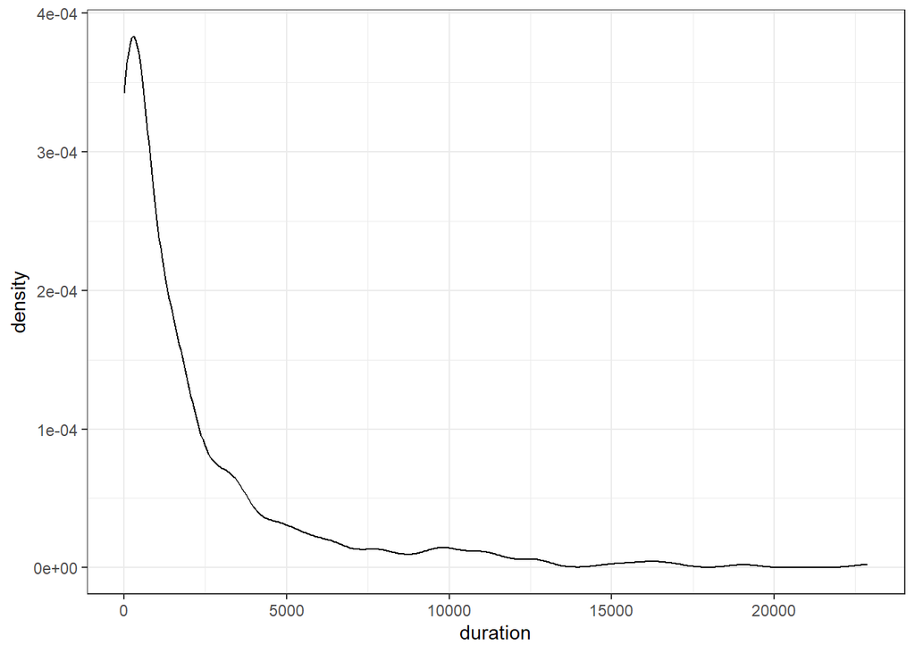

```r
ggplot(navco, aes(x=duration)) + geom_density() + theme_bw()
```

Describe some of the other variables in this dataset

## Tactics and outcomes

One of the central goals of the research in the NAVCO data was to look at the impacts of movement tactics on movement outcomes. The `tactic` variable shows whether a movement used violence or nonviolence. What do we need in order to see whether a relationship exists between these two characteristics?

## gtsummary

```r
navco|>

  select(goal, outcome, tactic)|>
  tbl_summary(by =tactic)
```

| **Characteristic** | **non-violence**, N = 169<sup>1</sup> | **violence**, N = 220<sup>1</sup> |
| --- | --- | --- |
| goal |  |  |
| other | 4 (2.4%) | 4 (1.8%) |
| regime change | 141 (83%) | 128 (58%) |
| secession | 10 (5.9%) | 50 (23%) |
| self-determination | 14 (8.3%) | 38 (17%) |
| outcome |  |  |
| failure | 53 (31%) | 142 (65%) |
| limited success | 22 (13%) | 22 (10%) |
| success | 94 (56%) | 56 (25%) |

<sup>1</sup> n (%)

```r
navco|>
  mutate(DURATION = as.numeric(DURATION))|>
  select(DURATION, STATESUP)|>
  tbl_summary(by=STATESUP)
```

| **Characteristic** | **0**, N = 284<sup>1</sup> | **1**, N = 105<sup>1</sup> |
| --- | --- | --- |
| DURATION | 590 (113, 1,897) | 1,826 (704, 4,098) |

<sup>1</sup> Median (IQR)